# Project2 - Child Mortality & Healthcare

Topic Name

**Child Mortality & Healthcare**

Team Members

| **Jenish Vinodbhai Dhaduk - 989354198 \|\| Aditi Gala - 989323325** |
| --- |

[figure not shown]

Table of Contents

```python
%%javascript
$.getScript('https://kmahelona.github.io/ipython_notebook_goodies/ipython_notebook_toc.js')
```

## 1. Objective

World Health Organization(WHO) began their journey on 7 April 1948 – a date we now celebrate every year as World Health Day. WHO has are now more than 7000 people from more than 150 countries. They work closely with decision-makers: Ministries of Health, government agencies, other government departments at the national level. Their engagement with the United Nations at the global, regional, and country-level is also a major asset. WHO wants to make people aware of the causes affecting the Child mortality rate. As child deaths occur due to various factors and factors vary from country to country. It becomes very much important to understand the countries demographics before starting any campaign.

In order to start a campaign around the world, our stakeholders, the board members of WHO need to have all the necessary information that will help decide the kind of campaigns to run. It might help them in distibuting the resources in a more organized and efficient manner, which can save a lot of man power, money and other medical resources as well. So, those saved resources can be used elsewhere thus improving child healthcare globally.

For carrying out this analysis, the dataset is collected from the [Global Heath Observatory (GHO)](http://apps.who.int/gho/data/node.main.COCD?lang=en), WHO's gateway to health related statistics for more that 1000 indicators for 194 counutries. Which contains the data for different diseases that cause child deaths for each country. The Data are organized to monitor progress towards the Sustainable Development Goals (SDGs), including health status indicators to monitor progress towards for the overall health goal, indicators to track equity in health indicators, and the indicators for the specific health and health-related targets of the SDGs.

## 2. Data Exploration

```python
import pandas as pd
import numpy as np
import random
import matplotlib.pyplot as plt
from mpl_toolkits.mplot3d import Axes3D
from sklearn.neighbors import KNeighborsClassifier

from matplotlib.colors import ListedColormap
from sklearn import datasets
from sklearn.cluster import KMeans
import sklearn.metrics as sm
from scipy.cluster.hierarchy import dendrogram, linkage, leaves_list
from sklearn.cluster import KMeans
from sklearn.preprocessing import MinMaxScaler

random.seed(50)
```

The code below is for loading the child mortality data into dataframes and for performing some exploratory analysis on the data. There are eight different datasets that will be combined into one final dataset after data cleaning.

```python
# Data for number of child deaths
malaria = pd.read_csv("number of child deaths by malaria.csv")
hivaids = pd.read_csv("number of child deaths by HIV AIDS.csv")
respiratory = pd.read_csv("number of child deaths by acute lower respiratory.csv")
trauma = pd.read_csv("number of child deaths by birth asphyxia and trauma.csv")
prematurity = pd.read_csv("number of child deaths by prematurity.csv")
other = pd.read_csv("number of child deaths by other conditions.csv")

# Data for rate of child deathes per 1000 live births
malaria_rate = pd.read_csv("rate of child deaths by malaria.csv")
hivaids_rate = pd.read_csv("rate of child deaths by HIV AIDS.csv")
respiratory_rate = pd.read_csv("rate of child deaths by acute lower respiratory.csv")
trauma_rate = pd.read_csv("rate of child deaths by birth asphyxia and trauma.csv")
prematurity_rate = pd.read_csv("rate of child deaths by prematurity.csv")
other_rate = pd.read_csv("rate of child deaths by other conditions.csv")
```

### 2.1 Number of columns in each dataset

```python
len(malaria.columns)
```

```
55
```

The datasets "malaria", "hivaids", "respiratory", "trauma", "prematurity", "other" and every other datasets include 55 columns.

### 2.2 Number of rows in each dataset

```python
len(malaria.index)
```

```
197
```

The datasets "malaria", "hivaids", "respiratory", "trauma", "prematurity", "other" and every other datasets include 197 rows.

### 2.3 Displaying the total number of child deaths by malaria for year 2017.

```python
mal = malaria["2017.2"].values
mal[0:3]=0
mal = list(map(int, mal))
sum(mal)
```

```
263182
```

The above calculated value is the total number of child deaths by malaria in the world for year 2017.

### 2.4 Displaying the mean for number child deaths by permaturity for year 2017.

```python
pre = prematurity["2017.2"].values
pre[0:3]=0
pre = list(map(int, pre))
mean = sum(pre)/194
mean
```

```
4970.953608247422
```

The above calculated value is the average for number of child deaths by prematurity for the year 2017.

## 3. Data Cleaning

1. Remove the top 3 rows from all dataframes which include descriptions that are not actual data points
2. Keep only column "2017.2" in all dataframes which represents the number/rate of child deaths for 0-4 years in 2017
3. Re-name the columns to identify cause of death in all 12 dataframes
4. Merge the 12 "2017.2" columns along with one "Country Name" column to create final clean data set
5. Convert the columns to numeric type

```python
n = len(malaria)
malaria = malaria[3:n]
malaria1 = malaria[["Unnamed: 0", "2017.2"]]
malaria1.rename(columns = {"Unnamed: 0": "country", "2017.2": "malaria"}, inplace = True)
#malaria1.head()

n = len(hivaids)
hivaids = hivaids[3:n]
hivaids1 = hivaids[["Unnamed: 0", "2017.2"]]
hivaids1.rename(columns = {"Unnamed: 0": "country", "2017.2": "hivaids"}, inplace = True)
#hivaids1.head()

n = len(respiratory)
respiratory = respiratory[3:n]
respiratory1 = respiratory[["Unnamed: 0", "2017.2"]]
respiratory1.rename(columns = {"Unnamed: 0": "country", "2017.2": "respiratory"}, inplace = True)
#respiratory1.head()

n = len(trauma)
trauma = trauma[3:n]
trauma1 = trauma[["Unnamed: 0", "2017.2"]]
trauma1.rename(columns = {"Unnamed: 0": "country", "2017.2": "trauma"}, inplace = True)
#trauma1.head()

n = len(other)
other = other[3:n]
other1 = other[["Unnamed: 0", "2017.2"]]
other1.rename(columns = {"Unnamed: 0": "country", "2017.2": "other_conditions"}, inplace = True)
#other1.head()

n = len(prematurity)
prematurity = prematurity[3:n]
prematurity1 = prematurity[["Unnamed: 0", "2017.2"]]
prematurity1.rename(columns = {"Unnamed: 0": "country", "2017.2": "prematurity"}, inplace = True)
prematurity1.head()
```

|  | country | prematurity |
| --- | --- | --- |
| 3 | Afghanistan | 14943 |
| 4 | Albania | 88 |
| 5 | Algeria | 4697 |
| 6 | Andorra | 1 |
| 7 | Angola | 11518 |

The output above shows the result of deleting the unnecessary rows and columns from the child death by prematuriy dataframe. Every other dataframe has the same structure with the last column identifying number child deaths by different causes.

```python
n = len(malaria_rate)
malaria_rate = malaria_rate[3:n]
malaria_rate1 = malaria_rate[["Unnamed: 0", "2017.2"]]
malaria_rate1.rename(columns = {"Unnamed: 0": "country", "2017.2": "malaria_rate"}, inplace = True)
#malaria1.head()

n = len(hivaids_rate)
hivaids_rate = hivaids_rate[3:n]
hivaids_rate1 = hivaids_rate[["Unnamed: 0", "2017.2"]]
hivaids_rate1.rename(columns = {"Unnamed: 0": "country", "2017.2": "hivaids_rate"}, inplace = True)
#hivaids1.head()

n = len(respiratory_rate)
respiratory_rate = respiratory_rate[3:n]
respiratory_rate1 = respiratory_rate[["Unnamed: 0", "2017.2"]]
respiratory_rate1.rename(columns = {"Unnamed: 0": "country", "2017.2": "respiratory_rate"}, inplace = True)
#respiratory_rate1.head()

n = len(trauma_rate)
trauma_rate = trauma_rate[3:n]
trauma_rate1 = trauma_rate[["Unnamed: 0", "2017.2"]]
trauma_rate1.rename(columns = {"Unnamed: 0": "country", "2017.2": "trauma_rate"}, inplace = True)
#trauma_rate1.head()

n = len(other_rate)
other_rate = other_rate[3:n]
other_rate1 = other_rate[["Unnamed: 0", "2017.2"]]
other_rate1.rename(columns = {"Unnamed: 0": "country", "2017.2": "other_conditions_rate"}, inplace = True)
#other_rate1.head()

n = len(prematurity_rate)
prematurity_rate = prematurity_rate[3:n]
prematurity_rate1 = prematurity_rate[["Unnamed: 0", "2017.2"]]
prematurity_rate1.rename(columns = {"Unnamed: 0": "country", "2017.2": "prematurity_rate"}, inplace = True)
prematurity_rate1.head()
```

|  | country | prematurity_rate |
| --- | --- | --- |
| 3 | Afghanistan | 13 |
| 4 | Albania | 2.6 |
| 5 | Algeria | 5.1 |
| 6 | Andorra | 2.2 |
| 7 | Angola | 9.3 |

The output above shows the result of deleting the unnecessary rows and columns from the death by prematuriy_rate dataframe. Every other child death rate dataframe has the same structure with the last column identifying child deaths rates per 1,000 live births for different causes.

```python
# Combining the dataframes
child_deaths = pd.concat([malaria1["country"],
                          malaria1["malaria"].astype(int),
                          hivaids1["hivaids"].astype(int),
                          respiratory1["respiratory"].astype(int),
                          trauma1["trauma"].astype(int),
                          prematurity1["prematurity"].astype(int),
                          other1["other_conditions"].astype(int),
                          malaria_rate1["malaria_rate"].astype(float),
                          hivaids_rate1["hivaids_rate"].astype(float),
                          respiratory_rate1["respiratory_rate"].astype(float),
                          trauma_rate1["trauma_rate"].astype(float),
                          prematurity_rate1["prematurity_rate"].astype(float),
                          other_rate1["other_conditions_rate"].astype(float)], axis =1)
child_deaths.head()
```

|  | country | malaria | hivaids | respiratory | trauma | prematurity | other_conditions | malaria_rate | hivaids_rate | respiratory_rate | trauma_rate | prematurity_rate | other_conditions_rate |
| --- | --- | --- | --- | --- | --- | --- | --- | --- | --- | --- | --- | --- | --- |
| 3 | Afghanistan | 68 | 17 | 11629 | 12379 | 14943 | 6631 | 0.1 | 0.0 | 10.1 | 10.7 | 13.0 | 5.8 |
| 4 | Albania | 0 | 2 | 27 | 27 | 88 | 18 | 0.0 | 0.1 | 0.8 | 0.8 | 2.6 | 0.5 |
| 5 | Algeria | 0 | 14 | 2892 | 3214 | 4697 | 1215 | 0.0 | 0.0 | 3.2 | 3.5 | 5.1 | 1.3 |
| 6 | Andorra | 0 | 0 | 0 | 0 | 1 | 0 | 0.0 | 0.0 | 0.0 | 0.0 | 2.2 | 0.0 |
| 7 | Angola | 6705 | 2693 | 16683 | 13121 | 11518 | 11805 | 5.4 | 2.2 | 13.5 | 10.6 | 9.3 | 9.6 |

```python
child_deaths.shape
```

```
(194, 13)
```

The table above is the result of combinining the 12 dataframes into one larger dataframe for easier analysis and comparison between the different child death causes (eg. malaria vs respiratory illness vs HIV/AIDS). This final dataframe has 194 rows (each representing a different country) and 13 columns (1 column representing country name, 6 columns for no. of child deaths by different causes, plus 6 colummns for child death rates by different causes.

## 4. Adaptation

The following additional columns are created to further our analysis:

1. Total number of child deaths by country = "total_number"
2. Total rate of child deaths by country = "total_rate"
3. % of deaths caused by illness (i.e deaths caused by malaria, hiv/aids & respiratory infection)
4. % of deaths caused by trauma and prematurity

```python
child_deaths["total_number"] = child_deaths[["malaria", "hivaids", "respiratory", "trauma", "prematurity",
                                             "other_conditions"]].sum(axis=1)

child_deaths["total_rate"] = child_deaths[["malaria_rate", "hivaids_rate", "respiratory_rate", "trauma_rate", "prematurity_rate",
                                             "other_conditions_rate"]].sum(axis=1)

child_deaths["illness_causes"] = child_deaths[["malaria", "hivaids", "respiratory"]].sum(axis=1)/child_deaths["total_number"]

child_deaths["non_illness_causes"] = child_deaths[["trauma", "prematurity"]].sum(axis=1)/child_deaths["total_number"]
```

```python
child_deaths.head(10)
```

|  | country | malaria | hivaids | respiratory | trauma | prematurity | other_conditions | malaria_rate | hivaids_rate | respiratory_rate | trauma_rate | prematurity_rate | other_conditions_rate | total_number | total_rate | illness_causes | non_illness_causes |
| --- | --- | --- | --- | --- | --- | --- | --- | --- | --- | --- | --- | --- | --- | --- | --- | --- | --- |
| 3 | Afghanistan | 68 | 17 | 11629 | 12379 | 14943 | 6631 | 0.1 | 0.0 | 10.1 | 10.7 | 13.0 | 5.8 | 45667 | 39.7 | 0.256509 | 0.598288 |
| 4 | Albania | 0 | 2 | 27 | 27 | 88 | 18 | 0.0 | 0.1 | 0.8 | 0.8 | 2.6 | 0.5 | 162 | 4.8 | 0.179012 | 0.709877 |
| 5 | Algeria | 0 | 14 | 2892 | 3214 | 4697 | 1215 | 0.0 | 0.0 | 3.2 | 3.5 | 5.1 | 1.3 | 12032 | 13.1 | 0.241523 | 0.657497 |
| 6 | Andorra | 0 | 0 | 0 | 0 | 1 | 0 | 0.0 | 0.0 | 0.0 | 0.0 | 2.2 | 0.0 | 1 | 2.2 | 0.000000 | 1.000000 |
| 7 | Angola | 6705 | 2693 | 16683 | 13121 | 11518 | 11805 | 5.4 | 2.2 | 13.5 | 10.6 | 9.3 | 9.6 | 62525 | 50.6 | 0.417129 | 0.394066 |
| 8 | Antigua and Barbuda | 0 | 0 | 1 | 1 | 2 | 1 | 0.0 | 0.0 | 0.5 | 0.5 | 1.2 | 0.4 | 5 | 2.6 | 0.200000 | 0.600000 |
| 9 | Argentina | 0 | 8 | 508 | 355 | 2187 | 515 | 0.0 | 0.0 | 0.7 | 0.5 | 2.9 | 0.7 | 3573 | 4.8 | 0.144416 | 0.711447 |
| 10 | Armenia | 0 | 0 | 53 | 33 | 120 | 36 | 0.0 | 0.0 | 1.4 | 0.9 | 3.1 | 0.9 | 242 | 6.3 | 0.219008 | 0.632231 |
| 11 | Australia | 0 | 0 | 33 | 123 | 237 | 144 | 0.0 | 0.0 | 0.1 | 0.4 | 0.8 | 0.5 | 537 | 1.8 | 0.061453 | 0.670391 |
| 12 | Austria | 0 | 0 | 8 | 29 | 47 | 36 | 0.0 | 0.0 | 0.1 | 0.3 | 0.5 | 0.4 | 120 | 1.3 | 0.066667 | 0.633333 |

The four additional columns can be seen in the table above to the right. These columns are created by performing aggregations on the other columns. They represent the total number of child deaths, total rate of child deaths per 1000 births, percentage of child deaths caused by illness and percentage of child deaths not caused by illness.

## 5. Visualization

### 5.1 Pie chart

```python
Totalmalaria = child_deaths['malaria'].sum()
Totalhivaids = child_deaths['hivaids'].sum()
Totalrespiratory = child_deaths['respiratory'].sum()
Totaltrauma = child_deaths['trauma'].sum()
Totalprematurity = child_deaths['prematurity'].sum()
Totalother_conditions = child_deaths['other_conditions'].sum()

Totalchilddeaths=[("deaths_by_malaria",Totalmalaria),
                  ("deaths_by_HIVaids",Totalhivaids),
                  ("deaths_by_respiratory",Totalrespiratory),
                  ("death_by_Trauma",Totaltrauma),
                  ("death_by_prematurity",Totalprematurity),
                  ("deaths_by_othercondiitons",Totalother_conditions)]

Totalchilddeaths
```

```
[('deaths_by_malaria', 263182),
 ('deaths_by_HIVaids', 75360),
 ('deaths_by_respiratory', 808701),
 ('death_by_Trauma', 671498),
 ('death_by_prematurity', 964365),
 ('deaths_by_othercondiitons', 529962)]
```

The sum is carried out for each and every cause for child_death to calculate the percentage in piechart.

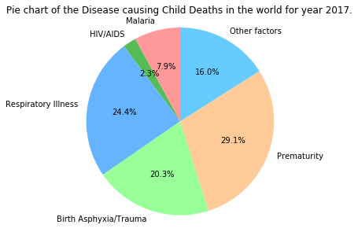

```python
def piechart():
    labels = ['Malaria', 'HIV/AIDS', 'Respiratory Illness', 'Birth Asphyxia/Trauma', 'Prematurity','Other factors']
    sizes = [Totalmalaria, Totalhivaids, Totalrespiratory, Totaltrauma, Totalprematurity, Totalother_conditions]
#colors
    colors = ['#ff9999','#55bb55','#66b3ff','#99ff99','#ffcc99','#66ccff']
    fig1, ax1 = plt.subplots()
    patches, texts, autotexts = ax1.pie(sizes, colors = colors, labels=labels, autopct='%1.1f%%', startangle=90)
    for text in texts:
        text.set_color('black')
    for autotext in autotexts:
        autotext.set_color('black')
# Equal aspect ratio ensures that pie is drawn as a circle
    ax1.axis('equal')
    plt.tight_layout()
    plt.title("Pie chart of the Disease causing Child Deaths in the world for year 2017.")

    return(plt.show())

piechart()
```

The pie chart above shows us the percentage of child deaths by different causes at the global level. As we can see, the leading cause is premature births, which accounts for almost 30% of all child deaths. The second leading cause for child deaths is respiratory illness followed by birth asphyxia/trauma.

### 5.2 Bar Stacked

```python
barstack = pd.DataFrame(child_deaths,columns=['country','malaria_rate', 'hivaids_rate','respiratory_rate','trauma_rate','prematurity_rate','total_rate'])
Sortbyrate = barstack.sort_values('total_rate',ascending=False)
Sortbyrate = Sortbyrate.assign(totalbyillness = lambda x: (x['malaria_rate'] + x['hivaids_rate'] + x['respiratory_rate'] ))
Sortbyrate = Sortbyrate.assign(totalbynonillness = lambda x: (x['trauma_rate'] + x['prematurity_rate'] ))
Sortbyrate5= Sortbyrate.head(5)
Sortbyrate5
```

|  | country | malaria_rate | hivaids_rate | respiratory_rate | trauma_rate | prematurity_rate | total_rate | totalbyillness | totalbynonillness |
| --- | --- | --- | --- | --- | --- | --- | --- | --- | --- |
| 35 | Central African Republic | 21.2 | 2.8 | 18.8 | 14.0 | 14.1 | 81.5 | 42.8 | 28.1 |
| 36 | Chad | 10.0 | 0.9 | 28.2 | 13.2 | 11.2 | 76.1 | 39.1 | 24.4 |
| 157 | Sierra Leone | 24.4 | 1.2 | 14.4 | 11.5 | 11.2 | 74.7 | 40.0 | 22.7 |
| 108 | Mali | 14.6 | 1.0 | 17.2 | 11.3 | 12.1 | 67.3 | 32.8 | 23.4 |
| 162 | Somalia | 0.7 | 0.2 | 25.6 | 15.8 | 10.5 | 64.7 | 26.5 | 26.3 |

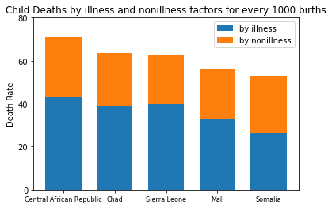

```python
N = 5

byillness = Sortbyrate5["totalbyillness"].values
bynonillness = Sortbyrate5["totalbynonillness"].values

ind = np.arange(N)    # the x locations for the groups
width = 0.7     # the width of the bars: can also be len(x) sequence

p1 = plt.bar(ind, byillness, width)
p2 = plt.bar(ind, bynonillness, width,
             bottom=byillness)

plt.ylabel('Death Rate')
plt.title('Child Deaths by illness and nonillness factors for every 1000 births')
plt.xticks(ind, ('Central African Republic', 'Chad', 'Sierra Leone', 'Mali', 'Somalia'),fontsize=8)
plt.yticks(np.arange(0, 81, 20))
plt.legend((p1[0], p2[0]), ('by illness', 'by nonillness'))

plt.show()
```

The stacked bar graph above shows us the top 5 countries that have the highest aggregated death rates. The blue part of the bars shows the proportion of death rates caused by illness (respirtatory+malaria) and the orange part shows the proportion of death rates not caused by a specific illness or disease (prematurity+trauma). As we can see, the child death rate from illness tends to have a slightly higher proportion for these countries.

### 5.3 Multiple colummn Bar

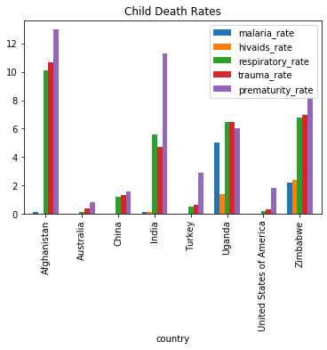

```python
def multibar():
    child_deaths_short = child_deaths.loc[child_deaths.country.isin(["Afghanistan", "India", "Uganda", "Turkey",
                                                                 "United States of America", "Australia",
                                                                 "China", "Zimbabwe"])]
    child_deaths_short.plot(x="country", y=["malaria_rate", "hivaids_rate", "respiratory_rate", "trauma_rate", "prematurity_rate"],
                        kind="bar", title="Child Death Rates",width = 0.7)
    return(plt.show())

multibar()
```

The multiple column bar chart above shows the child death rates (per 1000 live births) for 8 different selected countries. We can see some significant differences between the countries and also between the causes of death. For example, developed nations like Australia and USA have comparitively much lower child death rates especially. On the other hand, developing nations like Afghanistan, India, Uganda, and Zimbabwe have comparitively much higher child death rates. Even amongst the developing world we see major differences in malaria rates between African countries and Asian countries.

### 5.4 Scatter Plot.

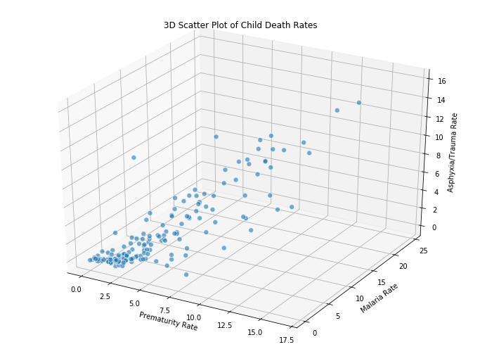

```python
fig = plt.figure(figsize=(12, 9))
Axes3D = Axes3D  # pycharm auto import
ax = fig.add_subplot(111, projection='3d')

xs = child_deaths["prematurity_rate"]
ys = child_deaths["malaria_rate"]
zs = child_deaths["trauma_rate"]

ax.scatter(xs, ys, zs, s=50, alpha=0.6, edgecolors='w')

ax.set_xlabel('Prematurity Rate')
ax.set_ylabel('Malaria Rate')
ax.set_zlabel('Asphyxia/Trauma Rate')

plt.title('3D Scatter Plot of Child Death Rates')
plt.show()
```

Each blue dot in the 3-Dimensional scatter plot above represents one country. This plot gives us an idea of the correlation between the child death rates caused by Prematurity (x axis), Malaria (y axis), and Asphyxia/Trauma (z axis). There seems to be an overall positive correlation between the variables but with some clustering, implying there are differences in the main cause for chil deaths depending on the country.

### 5.5 Correlation

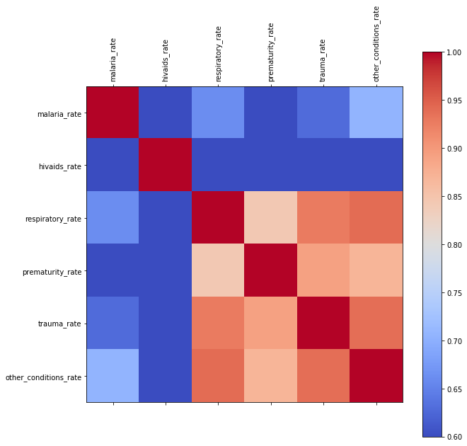

```python
def correlation():
    causes= pd.concat([child_deaths["country"],
                   child_deaths["malaria_rate"].astype(float),
                   child_deaths["hivaids_rate"].astype(float),
                   child_deaths["respiratory_rate"].astype(float),
                   child_deaths["prematurity_rate"].astype(float),
                   child_deaths["trauma_rate"].astype(float),
                   child_deaths["other_conditions_rate"].astype(float)],axis =1)
    causes.set_index("country", inplace = True)
    corr = causes.corr()
    fig = plt.figure(figsize=(10, 10))
    ax = fig.add_subplot(111)
    cax = ax.matshow(corr,cmap='coolwarm', vmin=0.6,vmax=1)
    fig.colorbar(cax)
    ticks = np.arange(0,len(causes.columns),1)
    ax.set_xticks(ticks)
    plt.xticks(rotation=90)
    ax.set_yticks(ticks)
    ax.set_xticklabels(causes.columns)
    ax.set_yticklabels(causes.columns)
    return(plt.show())

correlation()
```

The above correlation shows that **respiratory, trauma and other_conditions** are higly correlated with each other. Which help us to understand that in most countries child deaths by birth_asphyxia/trauma has **strong connection with child deaths by respiratory and other_Conditons** and vice versa. Where as Prematurity also shows high correlation with Birth_Asphyxia/Trauma.

## 6. Step by Step Hierarchical Clustering

```python
from sklearn.metrics.pairwise import euclidean_distances

def agglomerative(df):
    z = 1
    co=-26
    df = causes
    dist_df = pd.DataFrame(euclidean_distances(df))
    dist_df = dist_df.round(3)
    dist_df = dist_df.replace(0, 9999) # Replace 0 with 9999 to find smallest distance b/w different points only

    # Iterate through all points
    while z < len(df.index):
        smallest = dist_df.min().min()
        for i in dist_df.index:
            for j in dist_df.columns:
                if dist_df.loc[i,j] == smallest:
                    merge1 = i
                    merge2 = j
                if dist_df.loc[i,j] == smallest: break
            if dist_df.loc[i,j] == smallest: break


        # Create a new row by picking the smallest distance between new cluster and all other points
        new_row = []
        for i in dist_df.columns:
            min_i = min(dist_df.loc[merge1,i], dist_df.loc[merge2,i])
            new_row.append(min_i)

        new_ix = str(merge1)+"/"+str(merge2)
        dist_df.loc[new_ix] = new_row
        new_row.append(9999)
        dist_df[new_ix] = new_row
        dist_df = dist_df.drop(index=[merge1, merge2], columns=[merge1, merge2])


        #print(dist_df)
        if (z in [1, 25, 100, 150, 193]):
            print("---After", z," Iterations---")
            print("total number of clusters left:", len(dist_df))
            co=co+5
            print("last ",-co," cluster's ", dist_df.index[co:])
            print("--------------------------------------------")
            if z==193:
                print("All merged into one Big cluster")

        z = z + 1

    return(dist_df)
```

The code above defines a function for agglomerative hierarchical clustering on the child mortality data. The function uses a loop to iterate through the algorithm. In each iteration 1 row and 1 column is reduced in the distance matrix because it joins two clusters.

```python
dist_df = agglomerative(causes)
```

[output not shown]

[output cut: 17 more lines]

Here is the step by step explanation of Hierarchical Clustering. The above stats shows the number of clusters formed and also displays last **21, 16, 11, 6, 1** cluster indexes after **1st ,25th, 100th, 150th, 193th** iteration respectively. The indexes represent different countries in the dataset. It really helps to understand the working of the Hierarchical Clustering.

## 7. Dendrogram

The code below uses the SciPy library to create a dendrogram so we can see how the countries may be clustered using the 6 columns of child mortality rates data. The plot also includes two vertical lines from which two different k-values can be determined.

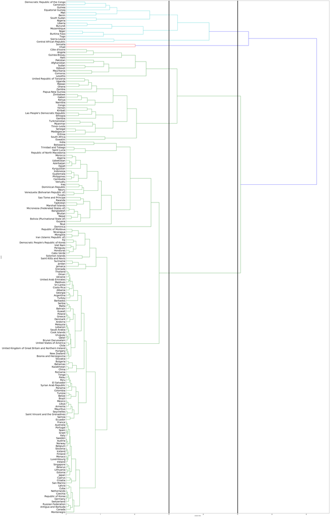

```python
Z = linkage(causes, 'complete')
plt.figure(figsize=(50, 100))
D = dendrogram(Z=Z, orientation="right", leaf_font_size=25, labels = causes.index)
plt.axvline(x=25, color='k', linewidth = 5.0)
plt.axvline(x=15, color='k', linewidth = 5.0)
plt.xlabel('sample index')
plt.ylabel('causes')
plt.show()
```

In the dendrogram above we see from the first vertical line that k = 7 (countries are in 7 groups) and from the second vertical line k = 4 (countries are in 4 groups). In the subsequent k-means & k-nn clustering analysis we have selected **k = 4** i.e. group the countries into 4 clusters.

## 8. Step by Step K-means

```python
def kmeans(df, k):
    centroids = []
    centroids_new = []
    for i in range(k):
        centroids_new.append(np.array([random.uniform(0,1.0), random.uniform(0,1.0), random.uniform(0,1.0), random.uniform(0,1.0), random.uniform(0,1.0)]))

    for i in range(50):
        centroids = centroids_new
        np.around(centroids,3)
        centroids = np.reshape(centroids, (4,5))
        df["dist1"] = np.sqrt((df.malaria_rate-centroids[0][0])**2 + (df.hivaids_rate-centroids[0][1])**2 + (df.respiratory_rate-centroids[0][2])**2 + (df.prematurity_rate-centroids[0][3])**2 + (df.trauma_rate-centroids[0][4])**2)
        df["dist2"] = np.sqrt((df.malaria_rate-centroids[1][0])**2 + (df.hivaids_rate-centroids[1][1])**2 + (df.respiratory_rate-centroids[1][2])**2 + (df.prematurity_rate-centroids[1][3])**2 + (df.trauma_rate-centroids[1][4])**2)
        df["dist3"] = np.sqrt((df.malaria_rate-centroids[2][0])**2 + (df.hivaids_rate-centroids[2][1])**2 + (df.respiratory_rate-centroids[2][2])**2 + (df.prematurity_rate-centroids[2][3])**2 + (df.trauma_rate-centroids[2][4])**2)
        df["dist4"] = np.sqrt((df.malaria_rate-centroids[3][0])**2 + (df.hivaids_rate-centroids[3][1])**2 + (df.respiratory_rate-centroids[3][2])**2 + (df.prematurity_rate-centroids[3][3])**2 + (df.trauma_rate-centroids[3][4])**2)
        values = df[["dist1", "dist2", "dist3", "dist4"]]
        #print(values)
        # Identify closest centroid
        df["Association"] = values.idxmin(axis=1)
        # Recentering centroids
        centroids_new = []
        centroid1_new = df[df.Association == "dist1"][["malaria_rate", "hivaids_rate", "respiratory_rate", "prematurity_rate", "trauma_rate"]].mean()
        centroid2_new = df[df.Association == "dist2"][["malaria_rate", "hivaids_rate", "respiratory_rate", "prematurity_rate", "trauma_rate"]].mean()
        centroid3_new = df[df.Association == "dist3"][["malaria_rate", "hivaids_rate", "respiratory_rate", "prematurity_rate", "trauma_rate"]].mean()
        centroid4_new = df[df.Association == "dist4"][["malaria_rate", "hivaids_rate", "respiratory_rate", "prematurity_rate", "trauma_rate"]].mean()
        centroids_new.append(np.array([centroid1_new, centroid2_new, centroid3_new, centroid4_new]))
        centroids_new = np.reshape(centroids_new, (4,5))
        np.around(centroids_new,3)
        # Check if old and new centroids are the same
        #print(np.array(centroids))
        #print(np.array(centroids_new))
        boolean = np.array(centroids_new)==np.array(centroids)
        #print(boolean)
        #print("end_iter:",i)
        if(boolean.all()==True): break
    return(df, centroids_new)
```

The code above is used to create a function for implementing the k-means algorithm that **accepts a dataframe and k parameter (k = 4 from dendrogram above).** We first establish a set of k random centroids the iterate through the k-means algorithm until there is no change in the location of the centroids. The data does not need to be normalized because all columns are on the same scale.

```python
df_cluster, centroids = kmeans(causes, 4)
print("Cluster 1:")
#print(df_cluster[df_cluster.Association == "dist1"].head())
print(df_cluster[df_cluster.Association == "dist1"].index)
print("Average Child Death Rates for this cluster:")
print(df_cluster[df_cluster.Association == "dist1"].mean())

print("\nCluster 2:")
#print(df_cluster[df_cluster.Association == "dist2"].head())
print(df_cluster[df_cluster.Association == "dist2"].index)
print("Average Child Death Rates for this cluster:")
print(df_cluster[df_cluster.Association == "dist2"].mean())

print("\nCluster 3:")
#print(df_cluster[df_cluster.Association == "dist3"].head())
print(df_cluster[df_cluster.Association == "dist3"].index)
print("Average Child Death Rates for this cluster:")
print(df_cluster[df_cluster.Association == "dist3"].mean())

print("\nCluster 4:")
#print(df_cluster[df_cluster.Association == "dist4"].head())
print(df_cluster[df_cluster.Association == "dist4"].index)
print("Average Child Death Rates for this cluster:")
print(df_cluster[df_cluster.Association == "dist4"].mean())


df_cluster["all_rate_sum"]= causes[["malaria_rate", "hivaids_rate", "respiratory_rate", "prematurity_rate", "trauma_rate"]].sum(axis=1)
df_cluster=df_cluster.sort_values("all_rate_sum")
df_cluster.tail(10)
```

```
Cluster 1:
Index(['Albania', 'Andorra', 'Antigua and Barbuda', 'Argentina', 'Armenia',
       'Australia', 'Austria', 'Bahamas', 'Bahrain', 'Barbados',
       ...
       'Syrian Arab Republic', 'Thailand', 'Tonga', 'Tunisia', 'Turkey',
       'Ukraine', 'United Arab Emirates',
       'United Kingdom of Great Britain and Northern Ireland',
       'United States of America', 'Uruguay'],
      dtype='object', name='country', length=102)
Average Child Death Rates for this cluster:
malaria_rate              0.012745
hivaids_rate              0.017647
respiratory_rate          0.700980
prematurity_rate          1.931373
trauma_rate               0.749020
other_conditions_rate     0.688235
dist1                     1.266916
dist2                     5.735540
dist3                    13.619245
dist4                    24.290994
dtype: float64

Cluster 2:
Index(['Algeria', 'Azerbaijan', 'Bangladesh', 'Bhutan',
       'Bolivia (Plurinational State of)', 'Botswana', 'Cambodia',
       'Democratic People's Republic of Korea', 'Dominica',
       'Dominican Republic', 'Egypt', 'Eritrea', 'Fiji', 'Guatemala', 'Guyana',
       'Indonesia', 'Iraq', 'Jamaica', 'Kyrgyzstan', 'Marshall Islands',
       'Micronesia (Federated States of)', 'Morocco', 'Namibia', 'Nauru',
       'Nepal', 'Niue', 'Paraguay', 'Philippines', 'Rwanda', 'Saint Lucia',
       'Sao Tome and Principe', 'Senegal', 'South Africa', 'Suriname',
       'Tajikistan', 'Republic of North Macedonia', 'Trinidad and Tobago',
       'Tuvalu', 'Uzbekistan', 'Vanuatu', 'Venezuela (Bolivarian Republic of)',
       'Viet Nam'],
      dtype='object', name='country')
Average Child Death Rates for this cluster:
malaria_rate              0.142857
hivaids_rate              0.352381
respiratory_rate          3.792857
prematurity_rate          5.721429
```

[output cut: 33 more lines]

```
       'Mali', 'Niger', 'Nigeria', 'Sierra Leone', 'Somalia', 'South Sudan',
       'Togo'],
      dtype='object', name='country')
Average Child Death Rates for this cluster:
malaria_rate             13.340000
hivaids_rate              1.646667
respiratory_rate         15.900000
prematurity_rate         10.506667
trauma_rate              10.953333
other_conditions_rate     9.940000
dist1                    25.233323
dist2                    21.174646
dist3                    15.109277
dist4                     7.363974
dtype: float64
```

| country | malaria_rate | hivaids_rate | respiratory_rate | prematurity_rate | trauma_rate | other_conditions_rate | dist1 | dist2 | dist3 | dist4 | Association | all_rate_sum |
| --- | --- | --- | --- | --- | --- | --- | --- | --- | --- | --- | --- | --- |
| Guinea | 14.0 | 1.2 | 15.6 | 7.7 | 8.5 | 9.2 | 22.635742 | 18.970660 | 13.441126 | 3.823785 | dist4 | 47.0 |
| Benin | 15.6 | 0.9 | 13.2 | 12.2 | 9.9 | 10.8 | 24.272447 | 20.227203 | 14.256202 | 4.114851 | dist4 | 51.8 |
| Somalia | 0.7 | 0.2 | 25.6 | 10.5 | 15.8 | 11.9 | 30.338427 | 25.438071 | 18.605034 | 16.716539 | dist4 | 52.8 |
| Equatorial Guinea | 13.8 | 5.6 | 12.9 | 10.8 | 10.4 | 8.5 | 23.277910 | 19.203341 | 12.875165 | 5.023213 | dist4 | 53.5 |
| South Sudan | 6.2 | 2.5 | 19.0 | 11.8 | 14.1 | 8.3 | 25.591733 | 20.478228 | 12.613389 | 8.537681 | dist4 | 53.6 |
| Nigeria | 9.6 | 2.5 | 18.3 | 11.5 | 12.0 | 10.0 | 25.018917 | 20.202457 | 12.628568 | 4.749526 | dist4 | 53.9 |
| Mali | 14.6 | 1.0 | 17.2 | 12.1 | 11.3 | 11.1 | 26.470641 | 22.110248 | 15.316802 | 2.520846 | dist4 | 56.2 |
| Sierra Leone | 24.4 | 1.2 | 14.4 | 11.2 | 11.5 | 12.0 | 31.389335 | 28.173801 | 22.963029 | 11.205029 | dist4 | 62.7 |
| Chad | 10.0 | 0.9 | 28.2 | 11.2 | 13.2 | 12.6 | 33.130866 | 28.547875 | 21.418367 | 12.981962 | dist4 | 63.5 |
| Central African Republic | 21.2 | 2.8 | 18.8 | 14.1 | 14.0 | 10.6 | 33.284828 | 29.198854 | 22.532228 | 9.680599 | dist4 | 70.9 |

In the output above we see the list of countries that belong to each of the 4 clusters according to the kmeans function. The average child mortality rates for each cluster is calculated for further analysis.

The dataframe table is also included above to show column "Association" which is used by the kmeans algorithm to identify which centroid is closest to each country & assign the cluster accordingly.

## 9. sklearn.cluster

The code below uses the sklearn library to perform kmeans clustering on the child mortality data where k = 4.

```python
causes2= pd.concat([child_deaths["country"],
                   child_deaths["other_conditions_rate"].astype(float),
                   child_deaths["respiratory_rate"].astype(float)],axis =1)
causes2.set_index("country", inplace = True)
causes2=causes.loc[:,['other_conditions_rate','respiratory_rate']]
orrate=causes2
orrate["other_conditions+respiratory"]=causes2[["other_conditions_rate", "respiratory_rate"]].sum(axis=1)


orrate = orrate.sort_values('other_conditions+respiratory')
causes2.tail(10)
causes2.drop("other_conditions+respiratory",axis=1,inplace=True)
km = KMeans(n_clusters=4, random_state=0).fit(causes2)
print("These are the 4 centroids for 4 clusters")
# Get the cluster centroids

print(km.cluster_centers_)
# Get the cluster labels
kmlab=km.labels_
causes2["clusters_no"] = kmlab
causes2.tail(10)
```

```
These are the 4 centroids for 4 clusters
[[ 0.84049587  0.97355372]
 [ 8.26333333 11.02666667]
 [10.75       21.18333333]
 [ 4.1972973   5.61621622]]
```

| country | other_conditions_rate | respiratory_rate | clusters_no |
| --- | --- | --- | --- |
| United Republic of Tanzania | 6.9 | 7.5 | 3 |
| United States of America | 0.7 | 0.2 | 0 |
| Uruguay | 0.5 | 0.4 | 0 |
| Uzbekistan | 1.6 | 2.7 | 0 |
| Vanuatu | 2.9 | 4.6 | 3 |
| Venezuela (Bolivarian Republic of) | 1.8 | 3.2 | 0 |
| Viet Nam | 1.5 | 2.9 | 0 |
| Yemen | 6.1 | 9.6 | 1 |
| Zambia | 6.9 | 8.1 | 1 |
| Zimbabwe | 5.6 | 6.8 | 3 |

The clusters column on the right identifies which cluster each country belongs to as follows: 0 = cluster0 (eg. Venezuela (Bolivarian Republic of)), 1 = cluster1 (eg. Yemen), 2 = cluster2 & 3 = cluster3(eg. Zimbabwe)

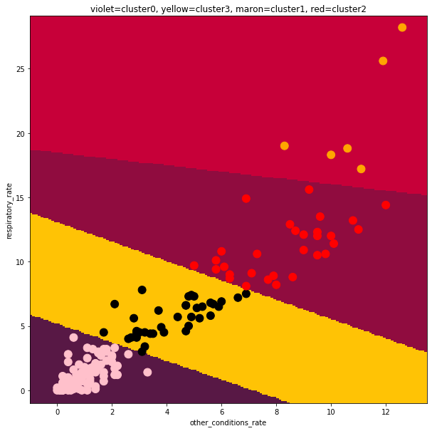

```python
def plotMesh():
    h = 0.1
    # Create color maps
    cmap_light = ListedColormap(['#581845','#900c3f','#c70039','#ffc305'])
    colormap = np.array(['pink', 'red', 'orange','black'])

    x_min2, x_max2 = causes2.other_conditions_rate.min() - 1, causes2.other_conditions_rate.max() + 1
    y_min2, y_max2 = causes2.respiratory_rate.min() - 1, causes2.respiratory_rate.max() + 1
    xx2, yy2 = np.meshgrid(np.arange(x_min2, x_max2, h),np.arange(y_min2, y_max2, h))
    Z2 = km.predict(np.c_[xx2.ravel(), yy2.ravel()])

    # Put the result into a color plot
    Z2 = Z2.reshape(xx2.shape)
    fig = plt.figure(figsize=(10,10))
    plt.pcolormesh(xx2, yy2, Z2, cmap = cmap_light)

    # Plot also the training points
    plt.scatter(causes2.other_conditions_rate, causes2.respiratory_rate, c = colormap[km.labels_], s = 120)
    plt.xlim(xx2.min(), xx2.max())
    plt.ylim(yy2.min(), yy2.max())
    plt.title('violet=cluster0, yellow=cluster3, maron=cluster1, red=cluster2')
    ax = fig.add_subplot(111)
 #   ax.title("yellow=cluster3, red=cluster2, maron=cluster1, violet=cluster0")
    #title(ax,'Top Plot')
    ax.set_xlabel('other_conditions_rate')
    ax.set_ylabel('respiratory_rate')
plotMesh()
```

The 2Dmesh plot represents the 4 clusters from dataframe "causes2" formed using kmeans clustering of the countries using the two parameters: respiratory illness mortality rate and other conditions mortality rate.

## 10. kNN Function

```python
dataframe= pd.concat([df_cluster["trauma_rate"].astype(float),
                   df_cluster["prematurity_rate"].astype(float),
                     df_cluster["Association"]],axis =1)

dataframe["index_no"] = [x for x in range(1, len(dataframe.values)+1)]
dataframe["trauma_rate+prematurity_rate"]=dataframe[["trauma_rate", "prematurity_rate"]].sum(axis=1)
dataframe = dataframe.replace({'Association': 'dist1'}, {'Association': 'cluster0'}, regex=True)
dataframe = dataframe.replace(to_replace="dist2", value='cluster1', regex=True)
dataframe = dataframe.replace(to_replace="dist3", value='cluster2', regex=True)
dataframe = dataframe.replace(to_replace="dist4", value='cluster3', regex=True)
#dataframe.head(5)
tprate = dataframe.sort_values('trauma_rate+prematurity_rate')
tprate.tail(10)
```

| country | trauma_rate | prematurity_rate | Association | index_no | trauma_rate+prematurity_rate |
| --- | --- | --- | --- | --- | --- |
| Mali | 11.3 | 12.1 | cluster3 | 191 | 23.4 |
| Nigeria | 12.0 | 11.5 | cluster3 | 190 | 23.5 |
| Afghanistan | 10.7 | 13.0 | cluster2 | 170 | 23.7 |
| Guinea-Bissau | 12.6 | 11.2 | cluster2 | 177 | 23.8 |
| Chad | 13.2 | 11.2 | cluster3 | 193 | 24.4 |
| South Sudan | 14.1 | 11.8 | cluster3 | 189 | 25.9 |
| Lesotho | 11.3 | 15.0 | cluster2 | 184 | 26.3 |
| Somalia | 15.8 | 10.5 | cluster3 | 187 | 26.3 |
| Pakistan | 10.6 | 16.7 | cluster2 | 173 | 27.3 |
| Central African Republic | 14.0 | 14.1 | cluster3 | 194 | 28.1 |

```python
def myKNNfunction(k,vec,dataframe,radius):
# distance from the given point to all other points is calculated and stored in new column called "distance"
    dataframe["distance"] = [0 for x in range(1, len(dataframe.values)+1)]
    for i in range(0, len(dataframe.index)):
        dataframe.distance[i] = np.sqrt((dataframe.trauma_rate[i]-vec[0])**2 + (dataframe.prematurity_rate[i]-vec[1])**2)

    totalmembers=0
    currentindex=-1
# the new sorted dataframe is cretead with distance value in ascending order.
    new = dataframe.sort_values('distance')


# the while loop will look for the points that are within the selected region.
#By comapring their distances with given "radius".
    while radius > new.distance[currentindex+1]:
        currentindex+=1
        totalmembers+=1

        #if there is no other point in the selected region.
    if totalmembers==0:
        return("No cluster found: try increasing radius value.")

    else:
        clust0=0
        clust1=0
        clust2=0
        clust3=0

        for j in range(0,totalmembers):
            if new.Association[j]=="cluster0":
                clust0+=1
            if new.Association[j]=="cluster1":
                clust1+=1
            if new.Association[j]=="cluster2":
                clust2+=1
            if new.Association[j]=="cluster3":
                clust3+=1

# Calculate among all the points that which cluster has the majority in the selected region and returns that cluster number.
        classify =  max(clust0,clust1,clust2,clust3)
        if classify == clust0:
            return("cluster0")
        if classify == clust1:
            return("cluster1")
        if classify == clust2:
            return("cluster2")
        if classify == clust3:
            return("cluster3")
```

The above myKNNfunction() is the function used to identify the cluster for any new entry. The function takes number of clusters(k), values of the parameter and name of dataframe. It returns the cluster number to which that new entry belongs.

```python
vector = [8.7,10.1]
radius = 4.0
classification_cluster = myKNNfunction(4,vector,dataframe,radius)
print(classification_cluster)
```

```
cluster2
```

The new point with values in vector is given with radius **4.0** and the assigned cluster is **"cluster2"**

```python
vector = [15.7,5.1]
radius = 6.0
classification_cluster = myKNNfunction(4,vector,dataframe,radius)
print(classification_cluster)
```

```
cluster1
```

The new point with values in vector is given with radius **6.0** and the assigned cluster is **"cluster1"**

```python
vector = [30,15]
radius = 3.0
classification_cluster = myKNNfunction(4,vector,dataframe,radius)
print(classification_cluster)
```

```
No cluster found: try increasing radius value.
```

The new point with values in vector is given with radius **3.0** and has found **no cluster** within the radius

```python
vector = [20,15]
radius = 12.5
classification_cluster = myKNNfunction(4,vector,dataframe,radius)
print(classification_cluster)
```

```
cluster2
```

```python
vector = [2.7,1.1]
radius = 10.0
classification_cluster = myKNNfunction(4,vector,dataframe,radius)
print(classification_cluster)
```

```
cluster0
```

The new point with values in vector is given with radius **10.0** and the assigned cluster is **"cluster0"**

## 11. Project Report

As all the Board members are aware that The World Health Organization (WHO) wants to make people aware of the causes affecting the Child mortality rate and implement global child healthcare campaigns accordingly. As child deaths occur due to various factors and factors vary from country to country. It becomes very important to understand the countries demographics and the differences in causes for death before starting any campaign. The Global Health Observatory data selected for anlaysis includes 6 different causes of child death: malaria, hiv/aids, respiratory illness, birth asphyxia/trauma, prematurity and other conditions. There were 12 tables total: 6 tables showing the number of child deaths by country (one for each cause) & 6 tables showing the rate of child death by country (one for each cause). This report focuses on the most recent data available which is from 2017.

Our analysis is based on answering three important questions:

1. **Which diseases are causing more child deaths all round the world?** The pie chart in section 5.1 helps to understand what are the most deadly causes for child deaths around the world. Prematurity & Respiratory Illness are the deadliest accounting for more that 50% of all child deaths.

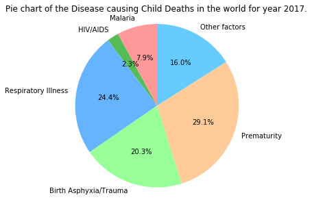

```python
piechart()
```

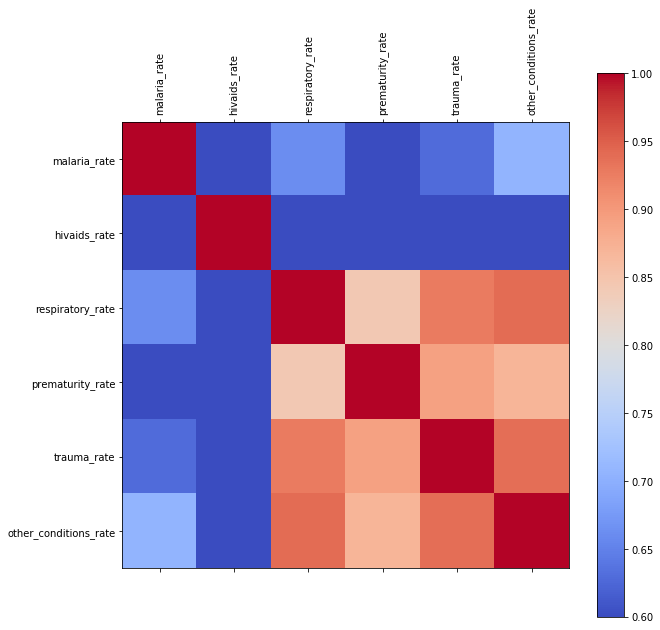

```python
correlation()
```

1. **What countries are affected the most & are there differences in the causes between countries?** The clustering analyses in this report show us there are major differences in the prevalence of child mortality both in terms of which countries have the highest rate and which diseases have the highest rate.

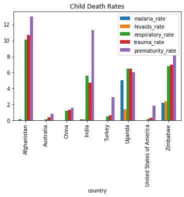

```python
multibar()
```

To understand different ways in which the data can be clustered we created a function that performs agglomerative **hierarchical clustering** on the dataset. A visual representation of the same analysis can be seen in the **Dendrogram** in section 7 above. Based on this analysis it was determined that k = 4 (aka 4 clusters) was an appropriate choice when performing clustering analysis on the data.

The next method of clustering was a supervised learning technique: **Knn** is a algorithm that finds the nearest point among the already plotted points and then decide which cluster to join. Most probably the nearest neighbour are likly to have similar parameters as that of the new point. So a function is created to form cluster of countries for the causes "prematurity" and "brain trauma".

Some important conclusions can be drawn from the clustering analysis:

- There are significant differences in the average child mortality rates for each cluster
- Clusters 3 & 4 have very high average child mortality rates compared to Clusters 1 & 2.
- Clusters 1 & 2 are mainly affected by prematurity and birth asphyxia/trauma
- Cluster 3, which includes countries like Ethiopia, Kenya, India, Myanmar etc., has a high average for all causes except malaria.
- Cluster 4 has very high child mortality rates for all 6 causes (including malaria). Countries in this cluster need the most help from WHO. These countries are Benin, Burkina Faso, Cameroon, Central African Republic, Chad, Democratic Republic of the Congo, Equatorial Guinea, Guinea, Mali, Niger, Nigeria, Sierra Leone, Somalia, South Sudan, and Togo.

WHO should know that Central Africa Republic, Chad, Somalia, South Sudan, Mali, Serria Leone seems to be having really hard time in addressing thess issues according to all the different clustering methods.

Camapigns should be targeted towards pregnant women & their families to spread awareness regarding the importance of health care during the different stages of pregnancy. That will help baby to develop to its full potential inside the womb. That might drastically reduce the child deaths rate, especially for birth trauma but also other correlated causes. WHO might want to educate women about all this causes for child deaths and should provide the necessary supplements & medications to the mother that can be used if needed. Additionally, efforts should me made to start Small clinics that provide necessay medication & other treatments to baby after their birth. That will expoentailly reduce the child_death rate for that region.

Only few women/families needs to be made aware about all these causes and their remedies in a particular region. We hope that afterwards those women will enlighten their fellow women as well about the causes and remedies in a particular region. Children are the future of any nation and all countries want to secure their future. WHO alongside the governments & citizens of the respective countries should take initatives to the brighter future.

## Originality

There is **no similar published work** found on same dataset as this analysis is carried out on a dataset which is merged **using 12 different datasets** solely for the purpose of measuring **the causes of child mortality** around the world and to find out the most affected countries for each cause for "World Health Organization".